# R Notebook

```r
library(knitr)
library(brms)
library(tidyverse)
library(dplyr)
library(tidyr)
library(ggplot2)
```

Jumping in to the zero inflated models. Some helpful stuff here has been [*How to analyze visual analog (slider) scale data?*](https://mvuorre.github.io/posts/2019-02-18-analyze-analog-scale-ratings-with-zero-one-inflated-beta-models/) by Matti Vuorre.

Following what he has done, specify a `bf()`. Here we are using regions as the grouping factor, just to get things going. I’ve specified no priors here. Getting things running is the goal here. There is no time series component here, ignoring this for now.

```r
zi_eight_regions_bf <-
  bf(
  irrfrac ~ eight_regions,
  phi ~ eight_regions,
  zi ~ eight_regions,
  family = zero_inflated_beta()
)

zi_eight_regions <-
  brm(
  formula = zi_eight_regions_bf,
  data = aei,
  cores = 4,
  seed = 17,
  file = "/Volumes/RachelExternal/Thesis/Thesis/fits/CL_Zero_Inflated_Fits/zero_inflated_eight_regions"
)

print(zi_eight_regions)
```

```
 Family: zero_inflated_beta
  Links: mu = logit; phi = log; zi = logit
Formula: irrfrac ~ eight_regions
         phi ~ eight_regions
         zi ~ eight_regions
   Data: aei (Number of observations: 1688)
Samples: 4 chains, each with iter = 2000; warmup = 1000; thin = 1;
         total post-warmup samples = 4000

Population-Level Effects:
                                    Estimate Est.Error l-95% CI u-95% CI Rhat Bulk_ESS Tail_ESS
Intercept                              -4.27      0.18    -4.64    -3.91 1.01      317      456
phi_Intercept                           3.78      0.24     3.28     4.23 1.01      374      758
zi_Intercept                          -39.78     33.10  -126.01    -5.09 1.01      325      370
eight_regionsafrica_sub_saharan        -0.60      0.20    -1.00    -0.19 1.01      353      556
eight_regionsamerica_north              0.41      0.20     0.01     0.82 1.01      350      585
eight_regionsamerica_south             -0.61      0.21    -1.01    -0.19 1.01      376      634
eight_regionsasia_west                  1.40      0.20     1.00     1.80 1.01      359      564
eight_regionseast_asia_pacific          1.03      0.21     0.63     1.46 1.01      384      600
eight_regionseurope_east                1.05      0.21     0.63     1.47 1.01      372      612
eight_regionseurope_west                1.11      0.21     0.70     1.54 1.01      352      470
phi_eight_regionsafrica_sub_saharan     0.07      0.26    -0.44     0.60 1.01      410      962
phi_eight_regionsamerica_north         -0.15      0.27    -0.67     0.40 1.01      436      999
phi_eight_regionsamerica_south          1.00      0.29     0.43     1.57 1.01      443      900
phi_eight_regionsasia_west             -1.13      0.27    -1.63    -0.60 1.01      410     1065
phi_eight_regionseast_asia_pacific     -1.05      0.28    -1.59    -0.51 1.01      429     1028
phi_eight_regionseurope_east           -1.24      0.27    -1.79    -0.70 1.01      420     1038
phi_eight_regionseurope_west           -1.04      0.28    -1.59    -0.49 1.01      438     1073
zi_eight_regionsafrica_sub_saharan     37.06     33.10     2.36   123.36 1.01      325      375
zi_eight_regionsamerica_north          38.52     33.10     3.78   124.89 1.01      326      370
zi_eight_regionsamerica_south          18.34     37.28   -44.05   111.72 1.00      329      350
zi_eight_regionsasia_west              36.72     33.11     2.04   123.17 1.01      325      375
zi_eight_regionseast_asia_pacific      39.42     33.10     4.76   125.71 1.01      326      369
zi_eight_regionseurope_east            24.58     34.68   -20.62   116.01 1.01      343      383
zi_eight_regionseurope_west            39.04     33.11     4.39   125.14 1.01      326      370

Samples were drawn using sampling(NUTS). For each parameter, Bulk_ESS
and Tail_ESS are effective sample size measures, and Rhat is the potential
scale reduction factor on split chains (at convergence, Rhat = 1).
```

This took about an hour to run. But rhats converged.

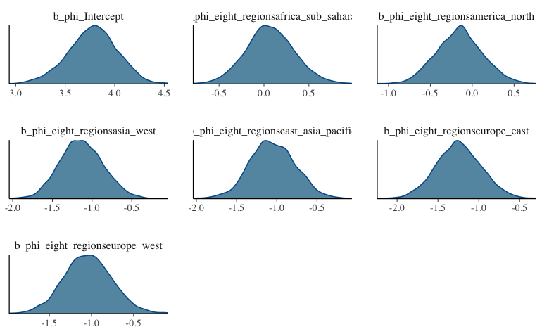

```r
mcmc_plot(zi_eight_regions, pars = c("b_phi_Intercept",
                        "b_phi_eight_regionsafrica_sub_saharan",
                        "b_phi_eight_regionsamerica_north",
                        "b_phi_eight_regionsasia_west",
                        "b_phi_eight_regionseast_asia_pacific",
                        "b_phi_eight_regionseurope_east",
                        "b_phi_eight_regionseurope_west"),
          type = "dens")
```

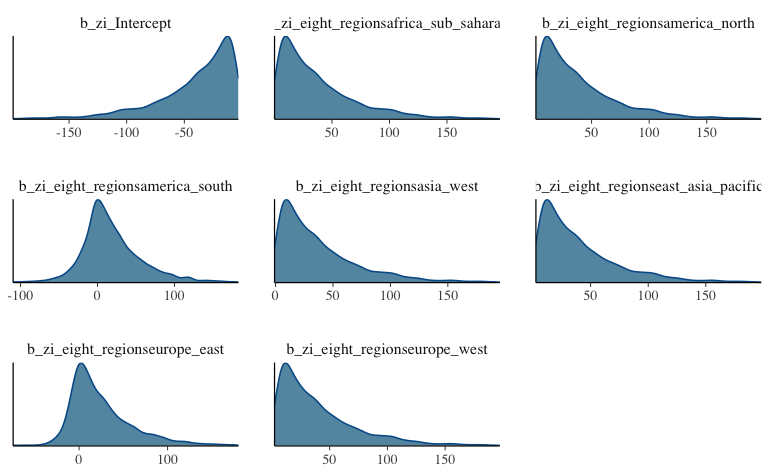

```r
mcmc_plot(zi_eight_regions, pars = "b_zi_", type = "dens")
```

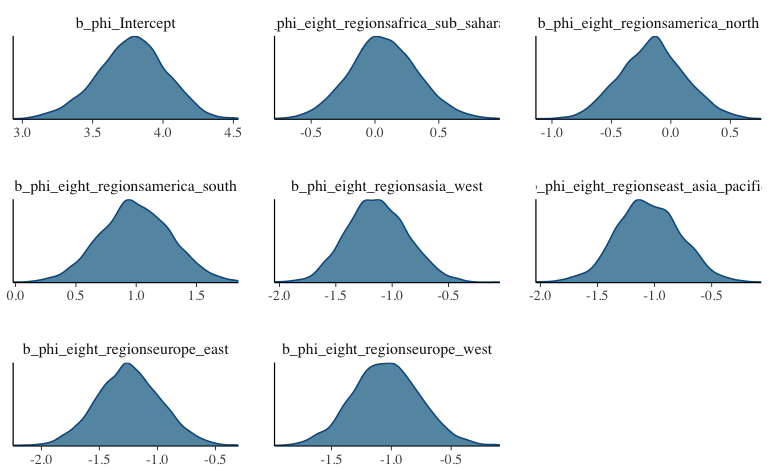

```r
mcmc_plot(zi_eight_regions, pars = "b_phi_", type = "dens")
```

Alright. Need to work out a bit of what is being communicated here. Majority of these plots seem similarly wide. Some of the Zi paramaters seem bounded by zero on either the top or the bottom end. Perhaps I am having a hard time with these because I have not transformed them in to the response scale. Let’s do that now.

All of the summary output is transformed via the logit ($\mu, zi$) or log ($\phi$) link. We need to transform them in to the response scale, use `exp` to transform $\phi$ and `plogis` for $\mu$ and $zi$ to be able to interpret them better. I am assuming that all parameters that are $\phi$ related have the same log link and need to be transformed via `exp` and others need`plogis` as they use the logit link. Is this a fair assumption?

```r
posterior_samples(zi_eight_regions, pars = "b_")[,1:24] %>%
  #the old fashioned way, brute force.
  mutate_at(c("b_phi_Intercept", "b_phi_eight_regionsafrica_sub_saharan",
              "b_phi_eight_regionsamerica_north",
              "b_phi_eight_regionsamerica_north",
              "b_phi_eight_regionsasia_west",
              "b_phi_eight_regionseast_asia_pacific",
              "b_phi_eight_regionseurope_east",
              "b_phi_eight_regionseurope_west"), exp) %>%
  mutate_at(vars(-c("b_phi_Intercept", "b_phi_eight_regionsafrica_sub_saharan",
              "b_phi_eight_regionsamerica_north",
              "b_phi_eight_regionsamerica_north",
              "b_phi_eight_regionsasia_west",
              "b_phi_eight_regionseast_asia_pacific",
              "b_phi_eight_regionseurope_east",
              "b_phi_eight_regionseurope_west")), plogis) %>%
  posterior_summary() %>%
  as.data.frame() %>%
  rownames_to_column("Parameter") %>%
  kable(digits = 2)
```

| Parameter | Estimate | Est.Error | Q2.5 | Q97.5 |
| --- | --- | --- | --- | --- |
| b_Intercept | 0.01 | 0.00 | 0.01 | 0.02 |
| b_phi_Intercept | 44.95 | 10.90 | 26.46 | 68.84 |
| b_zi_Intercept | 0.00 | 0.00 | 0.00 | 0.01 |
| b_eight_regionsafrica_sub_saharan | 0.36 | 0.05 | 0.27 | 0.45 |
| b_eight_regionsamerica_north | 0.60 | 0.05 | 0.50 | 0.69 |
| b_eight_regionsamerica_south | 0.35 | 0.05 | 0.27 | 0.45 |
| b_eight_regionsasia_west | 0.80 | 0.03 | 0.73 | 0.86 |
| b_eight_regionseast_asia_pacific | 0.74 | 0.04 | 0.65 | 0.81 |
| b_eight_regionseurope_east | 0.74 | 0.04 | 0.65 | 0.81 |
| b_eight_regionseurope_west | 0.75 | 0.04 | 0.67 | 0.82 |
| b_phi_eight_regionsafrica_sub_saharan | 1.11 | 0.30 | 0.65 | 1.82 |
| b_phi_eight_regionsamerica_north | 0.89 | 0.25 | 0.51 | 1.49 |
| b_phi_eight_regionsamerica_south | 0.73 | 0.06 | 0.61 | 0.83 |
| b_phi_eight_regionsasia_west | 0.33 | 0.09 | 0.20 | 0.55 |
| b_phi_eight_regionseast_asia_pacific | 0.36 | 0.10 | 0.20 | 0.60 |
| b_phi_eight_regionseurope_east | 0.30 | 0.08 | 0.17 | 0.50 |
| b_phi_eight_regionseurope_west | 0.37 | 0.11 | 0.20 | 0.61 |
| b_zi_eight_regionsafrica_sub_saharan | 0.99 | 0.03 | 0.91 | 1.00 |
| b_zi_eight_regionsamerica_north | 1.00 | 0.01 | 0.98 | 1.00 |
| b_zi_eight_regionsamerica_south | 0.67 | 0.45 | 0.00 | 1.00 |
| b_zi_eight_regionsasia_west | 0.99 | 0.05 | 0.88 | 1.00 |
| b_zi_eight_regionseast_asia_pacific | 1.00 | 0.00 | 0.99 | 1.00 |
| b_zi_eight_regionseurope_east | 0.76 | 0.40 | 0.00 | 1.00 |
| b_zi_eight_regionseurope_west | 1.00 | 0.01 | 0.99 | 1.00 |

Alright, again, need to look in to what this output means. One region (north africa) is encapsulated by the population level Intercept, zi_intercept, and phi_intercept. The phi_intercept is huge here, 44.95, but is similar to others as the difference between the intercept and the groups is captured by the specific “b_phi” value.

Here “b_zi” is a measure of the proportions of zeros present in the data set, as it is just a bernoulli distrobution? Is this correct? and How could it be that for europe west and east asia pacific that the probability of a country having an irrigation value of 0 is 1? Is this a correct interpretation?

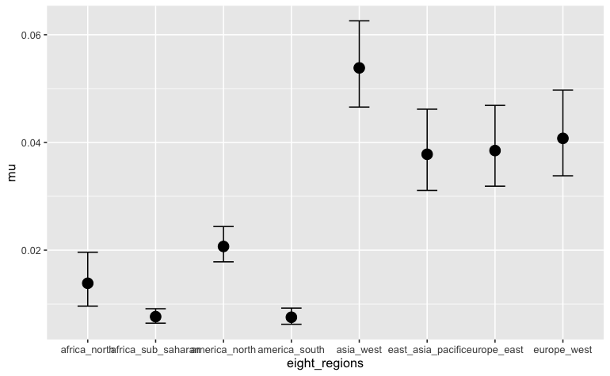

```r
conditional_effects(zi_eight_regions, dpar = "mu")
```

Ok so this is the spread of mu, the average for the response, or the proportion of irrigated land per country? Has this been transformed by the logit link as mentioned above? However, these don’t seem to be too off in a conceptual sense. Sub-saharan Africa and south America have lower rates of irrigation than northern africa (its dry?) and north america. Highest rates of irrigaion are found in west asia, which also makes a sense, as these areas are usually fertile and dry, hence the need for irrigation. Then europe, east and west, along with east asia have expectedly high rates of irrigation.

Some things to remember here though: each of these groups have a different number of countries that conclusions are being based off. (Ignore the NAs, they have zero irrigation fraction as per the Siebert Data).

```r
aei %>%
  group_by(eight_regions) %>%
  count()
```

| eight_regions | n |
| --- | --- |
| africa_north | 48 |
| africa_sub_saharan | 352 |
| america_north | 184 |
| america_south | 96 |
| asia_west | 200 |
| east_asia_pacific | 216 |
| europe_east | 160 |
| europe_west | 192 |
| NA | 400 |

So yeah, here Sub Saharan Africa has 352 samples as where South America has 96. Countries’ sizes vary and regions are not equally divided by a certain number of countries.

quick posterior check!

```
Using 10 posterior samples for ppc type 'dens_overlay' by default.
```

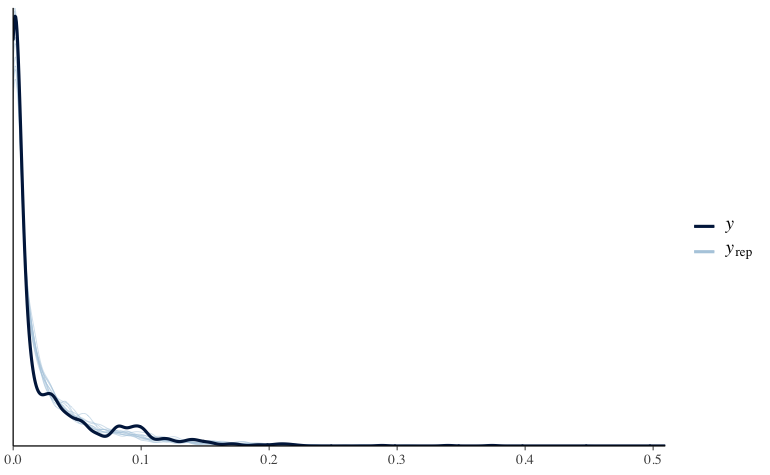

```r
pp_check(zi_eight_regions)
```

ahh this makes me so happy, as it looks so much better than the gaussian models I had been messing around with earlier.

I try this with 4 regions, just to keep practicing.

```r
zi_four_regions_bf <-
  bf(
  irrfrac ~ four_regions,
  phi ~ four_regions,
  zi ~ four_regions,
  family = zero_inflated_beta()

)
```

Now run a model.

```r
zi_four_regions <-
  brm(
  formula = zi_four_regions_bf,
  data = aei,
  cores = 4,
  seed = 17,
  control = list(adapt_delta = 0.99), #see if this decreases divergent trans
  file = "/Volumes/RachelExternal/Thesis/Thesis/fits/CL_Zero_Inflated_Fits/zero_inflated_four_regions"
)
```

```
Rows containing NAs were excluded from the model.Compiling Stan program...
```

```
starting worker pid=4473 on localhost:11124 at 11:58:33.011
starting worker pid=4487 on localhost:11124 at 11:58:33.281
starting worker pid=4501 on localhost:11124 at 11:58:33.549
starting worker pid=4515 on localhost:11124 at 11:58:33.820
```

```r
print(zi_four_regions)
```

```
 Family: zero_inflated_beta
  Links: mu = logit; phi = log; zi = logit
Formula: irrfrac ~ four_regions
         phi ~ four_regions
         zi ~ four_regions
   Data: aei (Number of observations: 1448)
Samples: 4 chains, each with iter = 2000; warmup = 1000; thin = 1;
         total post-warmup samples = 4000

Population-Level Effects:
                         Estimate Est.Error l-95% CI u-95% CI Rhat Bulk_ESS Tail_ESS
Intercept                   -4.79      0.08    -4.94    -4.63 1.00     1462     1821
phi_Intercept                3.85      0.10     3.65     4.03 1.00     1373     1889
zi_Intercept                -2.90      0.23    -3.36    -2.48 1.00     1678     1848
four_regionsamericas         0.66      0.10     0.45     0.87 1.00     1721     2410
four_regionsasia             1.81      0.10     1.61     2.01 1.00     1652     2563
four_regionseurope           1.62      0.11     1.40     1.84 1.00     1789     2113
phi_four_regionsamericas     0.03      0.14    -0.25     0.30 1.00     1874     2805
phi_four_regionsasia        -1.20      0.13    -1.48    -0.95 1.00     1763     2622
phi_four_regionseurope      -1.30      0.14    -1.57    -1.02 1.00     1701     2191
zi_four_regionsamericas      0.15      0.33    -0.49     0.81 1.00     2136     2180
zi_four_regionsasia          1.76      0.25     1.28     2.27 1.00     1778     2278
zi_four_regionseurope        1.00      0.28     0.49     1.55 1.00     1914     2311

Samples were drawn using sampling(NUTS). For each parameter, Bulk_ESS
and Tail_ESS are effective sample size measures, and Rhat is the potential
scale reduction factor on split chains (at convergence, Rhat = 1).
```

```r
posterior_samples(zi_four_regions, pars = "b_")[,1:12] %>%
  #the old fashioned way, brute force.
  mutate_at(c("b_phi_Intercept", "b_phi_four_regionsamericas",
              "b_phi_four_regionsasia",
              "b_phi_four_regionseurope"), exp) %>%
  mutate_at(vars(-c("b_phi_Intercept", "b_phi_four_regionsamericas",
              "b_phi_four_regionsasia",
              "b_phi_four_regionseurope")), plogis) %>%
  posterior_summary() %>%
  as.data.frame() %>%
  rownames_to_column("Parameter") %>%
  kable(digits = 2)
```

| Parameter | Estimate | Est.Error | Q2.5 | Q97.5 |
| --- | --- | --- | --- | --- |
| b_Intercept | 0.01 | 0.00 | 0.01 | 0.01 |
| b_phi_Intercept | 47.02 | 4.53 | 38.54 | 56.16 |
| b_zi_Intercept | 0.05 | 0.01 | 0.03 | 0.08 |
| b_four_regionsamericas | 0.66 | 0.02 | 0.61 | 0.70 |
| b_four_regionsasia | 0.86 | 0.01 | 0.83 | 0.88 |
| b_four_regionseurope | 0.83 | 0.02 | 0.80 | 0.86 |
| b_phi_four_regionsamericas | 1.04 | 0.15 | 0.78 | 1.35 |
| b_phi_four_regionsasia | 0.30 | 0.04 | 0.23 | 0.39 |
| b_phi_four_regionseurope | 0.28 | 0.04 | 0.21 | 0.36 |
| b_zi_four_regionsamericas | 0.54 | 0.08 | 0.38 | 0.69 |
| b_zi_four_regionsasia | 0.85 | 0.03 | 0.78 | 0.91 |
| b_zi_four_regionseurope | 0.73 | 0.05 | 0.62 | 0.82 |

```r
NA
```

Yeah, ok. Similar stuff here as the previous analysis. The dispersion coeffs are still extremely large. Some the zi coeffs have come down from one

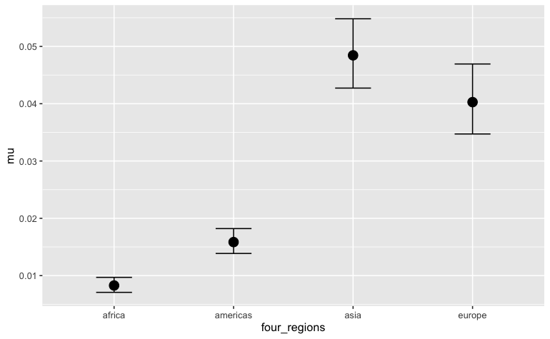

```r
conditional_effects(zi_four_regions, dpar = "mu")
```

```
Using 10 posterior samples for ppc type 'dens_overlay' by default.
```

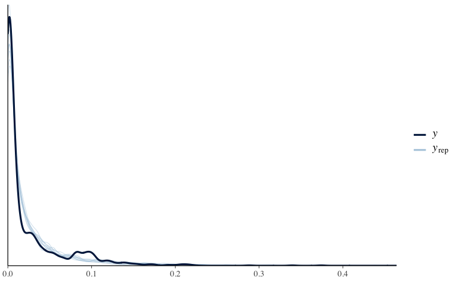

```r
pp_check(zi_four_regions)
```